# Lesson 14: R for Biochemistry & Molecular Biology

Modesto

2022-12-14 (17:12 h)

# Wellcome & Disclaimer

This site contains the materials for the *Coding tools for Biochemistry & Molecular Biology* (Herramientas de Programación para Bioquímica y Biología Molecular) course of fall 2022 in the Bachelor’s Degree in Biochemistry @UAM. This materials are the basis for GitHub-pages-based website that can be accessed [here](https://mredrejo.github.io/HPBBM2022/). Detailed academic information about the course contents, dates and assessment only can be found at the UAM Moodle site.

All this material is open access and it is shared under [CC BY-NC](https://creativecommons.org/licenses/by-nc/2.0/) license.

# Working with sequences

## Regular expressions as a shortcut to explore sequence

Biological data, like protein or nucleic acid sequences can be stored and explored in different formats, each following its own structure. As you can imagine, that facilitates the use of *regular expressions* in any programming language to access that data. The use of regular expressions in R is similar to other languages, particularly, to the use you learnt in Python. Anyway, I suggest that you have a look to the References below. However, for advanced manipulation of string object, I’d advice the package [Strings](https://stringr.tidyverse.org/).

In the code below, we are going to use some simple regular expressions to explore and analyze the data in a multifasta file containing the whole proteome of the bacteria *Bacillus thuringiensis HER1410.*

```r
# read the text file with readLines()
proteome <- readLines("data/HER1410.fasta")
# number of sequences in the multifasta using grep
length(grep(proteome, pattern = ">"))
```

```
## [1] 5807
```

```r
# extract of recombinases
grep("recombinase", proteome, value = TRUE)
```

```
##  [1] ">QKO37045.1 recombinase RecA (plasmid) [Bacillus thuringiensis]"
##  [2] ">QKO36998.1 recombinase family protein (plasmid) [Bacillus thuringiensis]"
##  [3] ">QKO36701.1 DDE-type integrase/transposase/recombinase (plasmid) [Bacillus thuringiensis]"
##  [4] ">QKO36696.1 tyrosine recombinase XerS (plasmid) [Bacillus thuringiensis]"
##  [5] ">QKO36060.1 tyrosine-type recombinase/integrase [Bacillus thuringiensis]"
##  [6] ">QKO36057.1 tyrosine-type recombinase/integrase [Bacillus thuringiensis]"
##  [7] ">QKO35589.1 recombinase family protein [Bacillus thuringiensis]"
##  [8] ">QKO35551.1 tyrosine-type recombinase/integrase [Bacillus thuringiensis]"
##  [9] ">QKO35280.1 recombinase family protein [Bacillus thuringiensis]"
## [10] ">QKO34873.1 site-specific tyrosine recombinase XerD [Bacillus thuringiensis]"
## [11] ">QKO34618.1 tyrosine recombinase XerC [Bacillus thuringiensis]"
## [12] ">QKO34567.1 recombinase RecA [Bacillus thuringiensis]"
## [13] ">QKO34482.1 recombinase family protein [Bacillus thuringiensis]"
## [14] ">QKO32507.1 recombinase RecQ [Bacillus thuringiensis]"
## [15] ">QKO32484.1 tyrosine-type recombinase/integrase [Bacillus thuringiensis]"
```

```r
# enzymes (aka '-ases')
head(grep("ase", proteome, value = TRUE))
```

```
## [1] ">QKO37046.1 helicase DnaB (plasmid) [Bacillus x1]"
## [2] ">QKO37045.1 recombinase RecA (plasmid) [Bacillus thuringiensis]"
## [3] ">QKO37043.1 IS3 family transposase (plasmid) [Bacillus thuringiensis]"
## [4] ">QKO37040.1 serine acetyltransferase (plasmid) [Bacillus thuringiensis]"
## [5] ">QKO37039.1 O-antigen ligase family protein (plasmid) [Bacillus thuringiensis]"
## [6] ">QKO37026.1 HK97 family phage prohead protease (plasmid) [Bacillus thuringiensis]"
```

```r
head(grep("ase", proteome, value = TRUE, ignore.case = TRUE))  #lower- & uppercase
```

```
## [1] ">QKO37046.1 helicase DnaB (plasmid) [Bacillus x1]"
## [2] ">QKO37045.1 recombinase RecA (plasmid) [Bacillus thuringiensis]"
## [3] ">QKO37043.1 IS3 family transposase (plasmid) [Bacillus thuringiensis]"
## [4] ">QKO37040.1 serine acetyltransferase (plasmid) [Bacillus thuringiensis]"
## [5] ">QKO37039.1 O-antigen ligase family protein (plasmid) [Bacillus thuringiensis]"
## [6] "SMSCDIDPTEIITRLTPLGTRIESKNEGATDASEARLTIESVNNGVPYIDHPSGIKEFGIQGKSITWDDV"
```

```r
# extract names
fastanames <- proteome[grep(proteome, pattern = ">")]  #extract the names of the sequences
# remove some pattern
head(sub(">", "", grep("ase", proteome, value = TRUE, ignore.case = TRUE)),
    20)
```

```
##  [1] "QKO37046.1 helicase DnaB (plasmid) [Bacillus x1]"
##  [2] "QKO37045.1 recombinase RecA (plasmid) [Bacillus thuringiensis]"
##  [3] "QKO37043.1 IS3 family transposase (plasmid) [Bacillus thuringiensis]"
##  [4] "QKO37040.1 serine acetyltransferase (plasmid) [Bacillus thuringiensis]"
##  [5] "QKO37039.1 O-antigen ligase family protein (plasmid) [Bacillus thuringiensis]"
##  [6] "SMSCDIDPTEIITRLTPLGTRIESKNEGATDASEARLTIESVNNGVPYIDHPSGIKEFGIQGKSITWDDV"
##  [7] "LEANTKQLEAEQKRLTSSFKLQNAELGANASEADKLELAQKQLRQQMEMTDRVVHNLEQQLSAAKRVYGE"
##  [8] "GASENVLTLAKVYDVDLNEATRGAGQLMSQFGLSTQQTFDLLAAGAQAGLNYSDELFDNLSEYAPLFKQA"
##  [9] "STVEYFSEAWSSFIEMMHEFFDPIGQFFSELWSGIVETASSWWSNLVTTASELWSQLTQAWQETWNTILT"
## [10] "FVVGKITEAEARSLGIEAGNGSVTVPEVIASEIITYAQEENLLRKYGSVHKTAGDMKYPVLVKKADANVR"
## [11] "QKO37026.1 HK97 family phage prohead protease (plasmid) [Bacillus thuringiensis]"
## [12] "QKO37024.1 terminase large subunit (plasmid) [Bacillus thuringiensis]"
## [13] "QKO37023.1 P27 family phage terminase small subunit (plasmid) [Bacillus thuringiensis]"
## [14] "QKO37022.1 HNH endonuclease (plasmid) [Bacillus thuringiensis]"
## [15] "QKO37016.1 nuclease (plasmid) [Bacillus thuringiensis]"
## [16] "QKO37013.1 DNA primase (plasmid) [Bacillus thuringiensis]"
## [17] "QKO37011.1 AAA family ATPase (plasmid) [Bacillus thuringiensis]"
## [18] "QKO37005.1 sigma-70 family RNA polymerase sigma factor (plasmid) [Bacillus thuringiensis]"
## [19] "QKO36998.1 recombinase family protein (plasmid) [Bacillus thuringiensis]"
## [20] "QKO36995.1 IS3 family transposase (plasmid) [Bacillus thuringiensis]"
```

```r
# regexpr returns the indices of the string where the match
# begins and the length of the match
(r <- regexpr("(.*)DNA(.*)", fastanames[1:200]))  #find all the lines with 'DNA' (only 200 lines to don't make it too long)
```

```
##   [1] -1 -1 -1 -1 -1 -1 -1 -1 -1 -1 -1 -1 -1 -1 -1 -1 -1 -1 -1 -1 -1 -1 -1 -1 -1
##  [26] -1 -1 -1 -1 -1 -1 -1 -1 -1 -1 -1  1 -1 -1 -1 -1 -1 -1 -1 -1 -1 -1 -1 -1 -1
##  [51] -1 -1 -1 -1 -1 -1 -1 -1 -1 -1 -1 -1 -1 -1 -1 -1 -1 -1 -1 -1 -1 -1 -1 -1 -1
##  [76] -1 -1  1 -1 -1 -1 -1 -1 -1 -1 -1 -1 -1 -1 -1 -1 -1 -1 -1 -1 -1 -1 -1 -1 -1
## [101] -1 -1 -1 -1 -1 -1 -1 -1 -1 -1 -1 -1 -1 -1 -1 -1 -1 -1 -1 -1 -1 -1 -1 -1 -1
## [126] -1 -1 -1 -1 -1 -1 -1 -1 -1 -1 -1 -1 -1 -1 -1 -1 -1 -1 -1 -1 -1 -1 -1 -1 -1
## [151] -1 -1 -1 -1 -1 -1 -1 -1 -1 -1 -1 -1 -1 -1  1 -1 -1 -1 -1 -1 -1 -1 -1 -1 -1
## [176] -1 -1 -1 -1 -1 -1 -1 -1 -1 -1 -1 -1 -1 -1 -1 -1 -1 -1 -1 -1 -1 -1 -1 -1 -1
## attr(,"match.length")
##   [1] -1 -1 -1 -1 -1 -1 -1 -1 -1 -1 -1 -1 -1 -1 -1 -1 -1 -1 -1 -1 -1 -1 -1 -1 -1
##  [26] -1 -1 -1 -1 -1 -1 -1 -1 -1 -1 -1 58 -1 -1 -1 -1 -1 -1 -1 -1 -1 -1 -1 -1 -1
##  [51] -1 -1 -1 -1 -1 -1 -1 -1 -1 -1 -1 -1 -1 -1 -1 -1 -1 -1 -1 -1 -1 -1 -1 -1 -1
##  [76] -1 -1 95 -1 -1 -1 -1 -1 -1 -1 -1 -1 -1 -1 -1 -1 -1 -1 -1 -1 -1 -1 -1 -1 -1
## [101] -1 -1 -1 -1 -1 -1 -1 -1 -1 -1 -1 -1 -1 -1 -1 -1 -1 -1 -1 -1 -1 -1 -1 -1 -1
## [126] -1 -1 -1 -1 -1 -1 -1 -1 -1 -1 -1 -1 -1 -1 -1 -1 -1 -1 -1 -1 -1 -1 -1 -1 -1
## [151] -1 -1 -1 -1 -1 -1 -1 -1 -1 -1 -1 -1 -1 -1 68 -1 -1 -1 -1 -1 -1 -1 -1 -1 -1
## [176] -1 -1 -1 -1 -1 -1 -1 -1 -1 -1 -1 -1 -1 -1 -1 -1 -1 -1 -1 -1 -1 -1 -1 -1 -1
## attr(,"index.type")
## [1] "chars"
## attr(,"useBytes")
## [1] TRUE
```

```r
# which ones?
(dna <- which(r > 0, arr.ind = TRUE))
```

```
## [1]  37  78 165
```

```r
dna.length <- attr(r, "match.length")[dna]
# extract the results with a loop
nombres <- list()
for (i in 1:length(dna)) {
    nombres[[i]] <- substr(fastanames[dna[i]], 1, 1 + dna.length[i])
}
head(nombres)
```

```
## [[1]]
## [1] ">QKO37013.1 DNA primase (plasmid) [Bacillus thuringiensis]"
##
## [[2]]
## [1] ">QKO36972.1 DNA-3-methyladenine glycosylase 2 family protein (plasmid) [Bacillus thuringiensis]"
##
## [[3]]
## [1] ">QKO36885.1 DNA topoisomerase III (plasmid) [Bacillus thuringiensis]"
```

## Working with sequences as objects

The use or regular expressions is very convenient for some quick overview of the (multi)fasta files, but not for more specific analyses. Working with sequences can be facilitated with diverse packages, being *seqinr* and *Biostrings* the more widely used in the literature.

In the following example, we are reading the same protein multifasta and we will obtain basic statistics, subset and save fasta sequences using *SeqinR (=seqinr)*.

NOTE: From this point on, we will show only the first 25 lines of the output of some code chunks (you will notice that the output starts and ends with *…*). Otherwise, this document is very long and difficult to follow. Run the code yourself to see the full returned output.

```r
# reading fasta and playing with it
# install.packages('seqinr')
library(seqinr)
prots <- read.fasta("data/HER1410.fasta")
str(prots)
```

```
...
## List of 5807
##  $ QKO37049.1: 'SeqFastadna' chr [1:67] "m" "t" "l" "t" ...
##   ..- attr(*, "name")= chr "QKO37049.1"
##   ..- attr(*, "Annot")= chr ">QKO37049.1 hypothetical protein HBA75_30905 (plasmid) [Bacillus thuringiensis]"
##  $ QKO37048.1: 'SeqFastadna' chr [1:142] "m" "k" "v" "l" ...
##   ..- attr(*, "name")= chr "QKO37048.1"
##   ..- attr(*, "Annot")= chr ">QKO37048.1 hypothetical protein HBA75_30875 (plasmid) [Bacillus thuringiensis]"
##  $ QKO37047.1: 'SeqFastadna' chr [1:326] "m" "e" "k" "k" ...
##   ..- attr(*, "name")= chr "QKO37047.1"
##   ..- attr(*, "Annot")= chr ">QKO37047.1 cytosolic protein (plasmid) [Bacillus thuringiensis]"
##  $ QKO37046.1: 'SeqFastadna' chr [1:146] "m" "e" "k" "q" ...
##   ..- attr(*, "name")= chr "QKO37046.1"
##   ..- attr(*, "Annot")= chr ">QKO37046.1 helicase DnaB (plasmid) [Bacillus x1]"
##  $ QKO37045.1: 'SeqFastadna' chr [1:359] "m" "a" "a" "t" ...
##   ..- attr(*, "name")= chr "QKO37045.1"
##   ..- attr(*, "Annot")= chr ">QKO37045.1 recombinase RecA (plasmid) [Bacillus thuringiensis]"
##  $ QKO37044.1: 'SeqFastadna' chr [1:110] "m" "s" "y" "d" ...
##   ..- attr(*, "name")= chr "QKO37044.1"
##   ..- attr(*, "Annot")= chr ">QKO37044.1 hypothetical protein HBA75_31045 (plasmid) [Bacillus thuringiensis]"
##  $ QKO37043.1: 'SeqFastadna' chr [1:293] "m" "k" "a" "a" ...
##   ..- attr(*, "name")= chr "QKO37043.1"
##   ..- attr(*, "Annot")= chr ">QKO37043.1 IS3 family transposase (plasmid) [Bacillus thuringiensis]"
##  $ QKO37042.1: 'SeqFastadna' chr [1:102] "m" "g" "k" "i" ...
##   ..- attr(*, "name")= chr "QKO37042.1"
##   ..- attr(*, "Annot")= chr ">QKO37042.1 helix-turn-helix domain-containing protein (plasmid) [Bacillus thuringiensis]"
...
```

```r
getName(prots)
```

```
...
##    [1] "QKO37049.1" "QKO37048.1" "QKO37047.1" "QKO37046.1" "QKO37045.1"
##    [6] "QKO37044.1" "QKO37043.1" "QKO37042.1" "QKO37041.1" "QKO37040.1"
##   [11] "QKO37039.1" "QKO37038.1" "QKO37037.1" "QKO37036.1" "QKO37035.1"
##   [16] "QKO37034.1" "QKO37033.1" "QKO37032.1" "QKO37031.1" "QKO37030.1"
##   [21] "QKO37029.1" "QKO37028.1" "QKO37027.1" "QKO37026.1" "QKO37025.1"
##   [26] "QKO37024.1" "QKO37023.1" "QKO37022.1" "QKO37021.1" "QKO37020.1"
##   [31] "QKO37019.1" "QKO37018.1" "QKO37017.1" "QKO37016.1" "QKO37015.1"
##   [36] "QKO37014.1" "QKO37013.1" "QKO37012.1" "QKO37011.1" "QKO37010.1"
##   [41] "QKO37009.1" "QKO37008.1" "QKO37007.1" "QKO37006.1" "QKO37005.1"
##   [46] "QKO37004.1" "QKO37003.1" "QKO37002.1" "QKO37001.1" "QKO37000.1"
##   [51] "QKO36999.1" "QKO36998.1" "QKO36997.1" "QKO36996.1" "QKO36995.1"
##   [56] "QKO36994.1" "QKO36993.1" "QKO36992.1" "QKO36991.1" "QKO36990.1"
##   [61] "QKO36989.1" "QKO36988.1" "QKO36987.1" "QKO36986.1" "QKO36985.1"
##   [66] "QKO36984.1" "QKO36983.1" "QKO36982.1" "QKO36981.1" "QKO36980.1"
##   [71] "QKO36979.1" "QKO36978.1" "QKO36977.1" "QKO36976.1" "QKO36975.1"
##   [76] "QKO36974.1" "QKO36973.1" "QKO36972.1" "QKO36971.1" "QKO36970.1"
##   [81] "QKO36969.1" "QKO36968.1" "QKO36967.1" "QKO36966.1" "QKO36965.1"
##   [86] "QKO36964.1" "QKO36963.1" "QKO36962.1" "QKO36961.1" "QKO36960.1"
##   [91] "QKO36959.1" "QKO36958.1" "QKO36957.1" "QKO36956.1" "QKO36955.1"
##   [96] "QKO36954.1" "QKO36953.1" "QKO36952.1" "QKO36951.1" "QKO36950.1"
##  [101] "QKO36949.1" "QKO36948.1" "QKO36947.1" "QKO36946.1" "QKO36945.1"
##  [106] "QKO36944.1" "QKO36943.1" "QKO36942.1" "QKO36941.1" "QKO36940.1"
##  [111] "QKO36939.1" "QKO36938.1" "QKO36937.1" "QKO36936.1" "QKO36935.1"
##  [116] "QKO36934.1" "QKO36933.1" "QKO36932.1" "QKO36931.1" "QKO36930.1"
##  [121] "QKO36929.1" "QKO36928.1" "QKO36927.1" "QKO36926.1" "QKO36925.1"
...
```

```r
prots[[1]]
```

```
##  [1] "m" "t" "l" "t" "l" "h" "n" "g" "d" "l" "n" "k" "l" "a" "r" "d" "t" "s" "q"
## [20] "d" "s" "i" "i" "l" "r" "v" "g" "e" "q" "e" "m" "v" "s" "l" "k" "s" "n" "g"
## [39] "d" "i" "y" "v" "k" "g" "k" "l" "v" "e" "n" "d" "k" "e" "v" "v" "d" "g" "m"
## [58] "r" "e" "l" "l" "m" "l" "s" "r" "k" "r"
## attr(,"name")
## [1] "QKO37049.1"
## attr(,"Annot")
## [1] ">QKO37049.1 hypothetical protein HBA75_30905 (plasmid) [Bacillus thuringiensis]"
## attr(,"class")
## [1] "SeqFastadna"
```

```r
seq <- getSequence(prots[[1]])
getName(prots[[1]])
```

```
## [1] "QKO37049.1"
```

```r
paste(seq, collapse = "")
```

```
## [1] "mtltlhngdlnklardtsqdsiilrvgeqemvslksngdiyvkgklvendkevvdgmrellmlsrkr"
```

```r
paste(prots[[1]], collapse = "")
```

```
## [1] "mtltlhngdlnklardtsqdsiilrvgeqemvslksngdiyvkgklvendkevvdgmrellmlsrkr"
```

```r
aaa(toupper(seq))
```

```
##  [1] "Met" "Thr" "Leu" "Thr" "Leu" "His" "Asn" "Gly" "Asp" "Leu" "Asn" "Lys"
## [13] "Leu" "Ala" "Arg" "Asp" "Thr" "Ser" "Gln" "Asp" "Ser" "Ile" "Ile" "Leu"
## [25] "Arg" "Val" "Gly" "Glu" "Gln" "Glu" "Met" "Val" "Ser" "Leu" "Lys" "Ser"
## [37] "Asn" "Gly" "Asp" "Ile" "Tyr" "Val" "Lys" "Gly" "Lys" "Leu" "Val" "Glu"
## [49] "Asn" "Asp" "Lys" "Glu" "Val" "Val" "Asp" "Gly" "Met" "Arg" "Glu" "Leu"
## [61] "Leu" "Met" "Leu" "Ser" "Arg" "Lys" "Arg"
```

```r
aaa(toupper(unlist(seq)))
```

```
##  [1] "Met" "Thr" "Leu" "Thr" "Leu" "His" "Asn" "Gly" "Asp" "Leu" "Asn" "Lys"
## [13] "Leu" "Ala" "Arg" "Asp" "Thr" "Ser" "Gln" "Asp" "Ser" "Ile" "Ile" "Leu"
## [25] "Arg" "Val" "Gly" "Glu" "Gln" "Glu" "Met" "Val" "Ser" "Leu" "Lys" "Ser"
## [37] "Asn" "Gly" "Asp" "Ile" "Tyr" "Val" "Lys" "Gly" "Lys" "Leu" "Val" "Glu"
## [49] "Asn" "Asp" "Lys" "Glu" "Val" "Val" "Asp" "Gly" "Met" "Arg" "Glu" "Leu"
## [61] "Leu" "Met" "Leu" "Ser" "Arg" "Lys" "Arg"
```

```r
aaa(toupper(as.vector(seq)))
```

```
##  [1] "Met" "Thr" "Leu" "Thr" "Leu" "His" "Asn" "Gly" "Asp" "Leu" "Asn" "Lys"
## [13] "Leu" "Ala" "Arg" "Asp" "Thr" "Ser" "Gln" "Asp" "Ser" "Ile" "Ile" "Leu"
## [25] "Arg" "Val" "Gly" "Glu" "Gln" "Glu" "Met" "Val" "Ser" "Leu" "Lys" "Ser"
## [37] "Asn" "Gly" "Asp" "Ile" "Tyr" "Val" "Lys" "Gly" "Lys" "Leu" "Val" "Glu"
## [49] "Asn" "Asp" "Lys" "Glu" "Val" "Val" "Asp" "Gly" "Met" "Arg" "Glu" "Leu"
## [61] "Leu" "Met" "Leu" "Ser" "Arg" "Lys" "Arg"
```

```r
pmw(toupper(unlist(seq)))
```

```
## [1] 7602.706
```

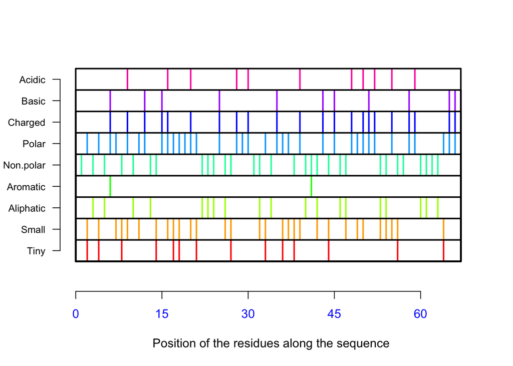

```
## $Compo
##
##  *  A  C  D  E  F  G  H  I  K  L  M  N  P  Q  R  S  T  V  W  Y
##  0  1  0  6  5  0  5  1  3  6 10  4  4  0  2  5  5  3  6  0  1
##
## $Prop
## $Prop$Tiny
## [1] 0.2089552
##
## $Prop$Small
## [1] 0.4477612
##
## $Prop$Aliphatic
## [1] 0.2835821
##
## $Prop$Aromatic
## [1] 0.02985075
##
## $Prop$Non.polar
## [1] 0.4477612
##
## $Prop$Polar
## [1] 0.5522388
##
## $Prop$Charged
## [1] 0.3432836
##
## $Prop$Basic
## [1] 0.1791045
##
## $Prop$Acidic
## [1] 0.1641791
##
##
## $Pi
## [1] 6.557213
```

```r
(stats1 <- AAstat(toupper(seq), plot = T))
```

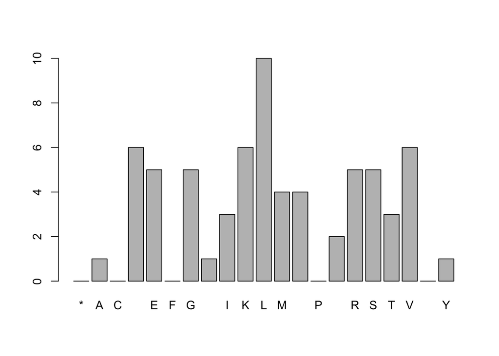

```r
barplot(stats1$Compo, bty = "7")
```

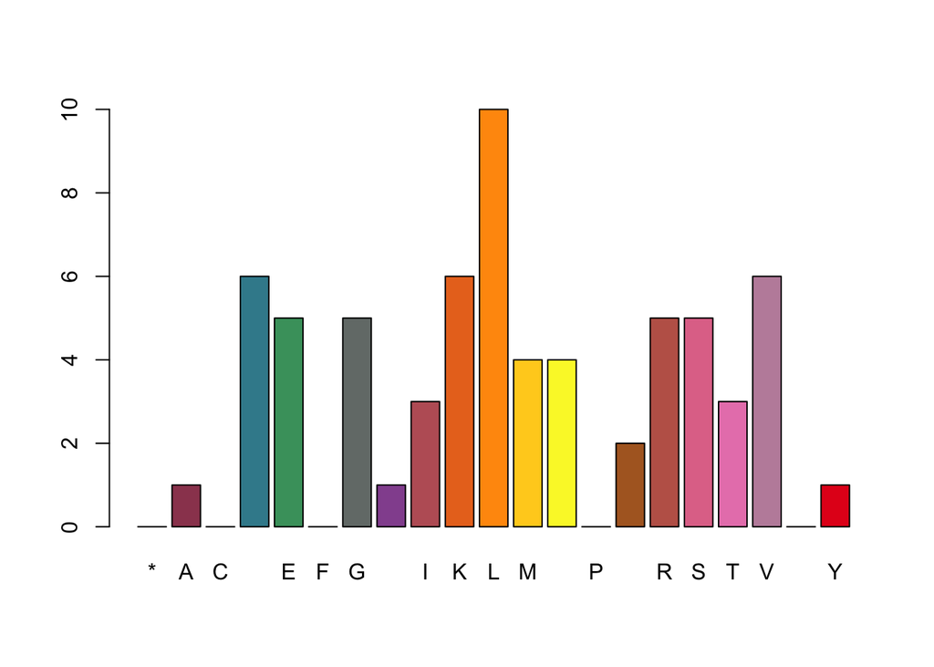

```r
# cool color palette
library(RColorBrewer)
coul = colorRampPalette(brewer.pal(9, "Set1"))(20)  #palette is expanded from 9 to 20 colors
barplot(stats1$Compo, col = coul, bty = "7")
```

```r
# dotplot
grep("recombinase", getAnnot(prots))
```

```
##  [1]    5   52  349  354  990  993 1461 1499 1770 2177 2432 2483 2568 4543 4566
```

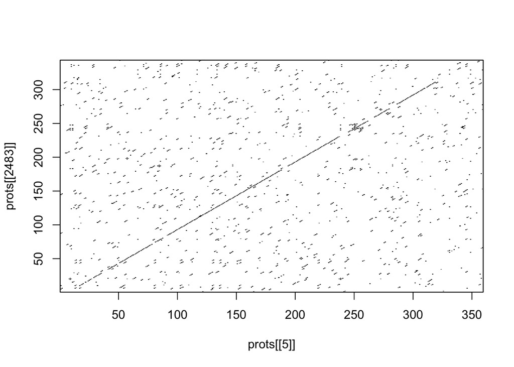

```r
dotPlot(prots[[5]], prots[[2483]], wsize = 3, nmatch = 2)
```

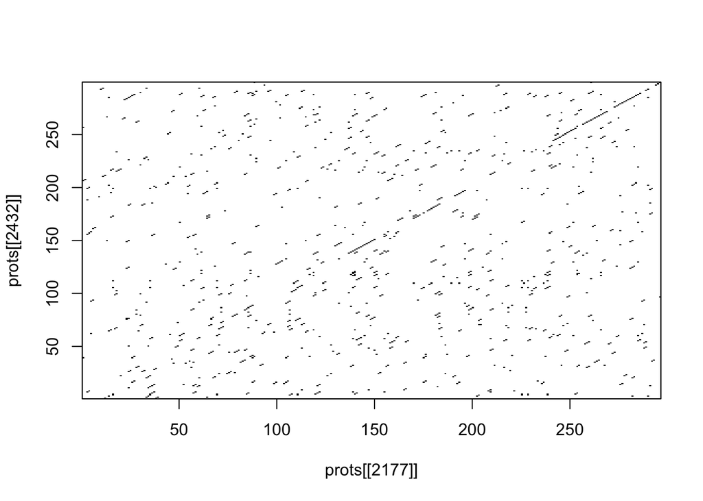

```r
dotPlot(prots[[2177]], prots[[2432]], wsize = 3, nmatch = 2)
```

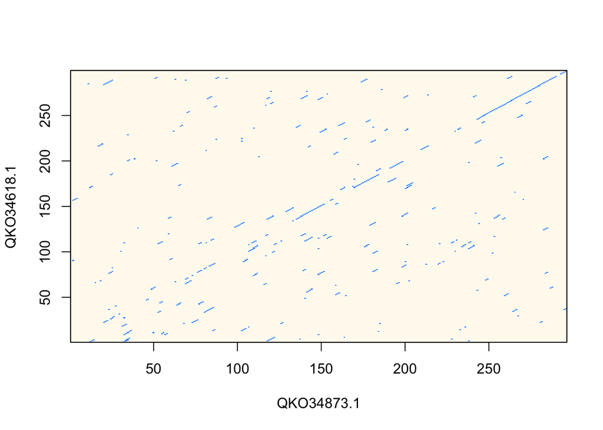

```r
dotPlot(prots[[2177]], prots[[2432]], col = c("floralwhite",
    "dodgerblue"), wsize = 6, nmatch = 3, xlab = getName(prots[[2177]]),
    ylab = getName(prots[[2432]]))
```

```r
# extract the recombinases to a new file
recs <- prots[grep("recombinase", getAnnot(prots))]
# save to a file
write.fasta(recs, names = names(recs), file.out = "data/recombinases.faa")
```

As you noticed in the code above, the function `read.fasta()` can read any (multi)fasta file containing a protein or nucleic acid sequence and create a list of lists. Thus, if you want to extract a sequence as a single element, you need to extract if from the list with `unlist()` or convert it to a vector with `as.vector()`.

Once you read the fasta, you can extract the headline name with `getName()` or the sequence with `getSequence()`. Additionally, you can obtain and plot basic stats or compare sequences using `dotPlot()`. Moreover, if you extract a subset of sequences, you can use `write.fasta()` to save those sequences in a new fasta file.

Finally, as in the example below, you can also play with a nucleotide sequence and obtain some useful data, like the `GC()` content, the encoded proteins or the reverse complementary sequence with `rev()` and `comp()`, respectively.

```r
# now the nt sequence
plasmid_nt <- read.fasta("data/HER1410nt.fasta")

count(unlist(plasmid_nt), 3)
```

```
##
##  aaa  aac  aag  aat  aca  acc  acg  act  aga  agc  agg  agt  ata  atc  atg  att
## 2150  705 1089 1420  715  253  321  484  900  437  525  601  992  589  955 1354
##  caa  cac  cag  cat  cca  ccc  ccg  cct  cga  cgc  cgg  cgt  cta  ctc  ctg  ctt
##  848  248  455  548  325   85  126  235  297  126  190  308  448  200  360  569
##  gaa  gac  gag  gat  gca  gcc  gcg  gct  gga  ggc  ggg  ggt  gta  gtc  gtg  gtt
## 1273  273  418  829  467  128  212  384  641  224  292  516  620  230  484  755
##  taa  tac  tag  tat  tca  tcc  tcg  tct  tga  tgc  tgg  tgt  tta  ttc  ttg  ttt
## 1093  547  501 1093  592  305  262  475  955  404  666  663 1174  615  889 1310
```

```r
count(unlist(plasmid_nt), 5)
```

```
##
## aaaaa aaaac aaaag aaaat aaaca aaacc aaacg aaact aaaga aaagc aaagg aaagt aaata
##   307   110   200   221   138    31    58    45   189    77   105    86   133
## aaatc aaatg aaatt aacaa aacac aacag aacat aacca aaccc aaccg aacct aacga aacgc
##   109   170   171   144    25    64    73    34    14    15    24    42    13
## aacgg aacgt aacta aactc aactg aactt aagaa aagac aagag aagat aagca aagcc aagcg
##    28    45    48    24    46    66   199    38    70   104    71    20    38
## aagct aagga aaggc aaggg aaggt aagta aagtc aagtg aagtt aataa aatac aatag aatat
##    61    97    33    40    70    96    13    55    84   112    80    52   116
## aatca aatcc aatcg aatct aatga aatgc aatgg aatgt aatta aattc aattg aattt acaaa
##    81    41    35    54   130    51    95    83   162    77   128   123   109
## acaac acaag acaat acaca acacc acacg acact acaga acagc acagg acagt acata acatc
##    54    63    67    27    18    20    24    52    34    39    44    37    27
## acatg acatt accaa accac accag accat accca acccc acccg accct accga accgc accgg
##    36    64    38    13    28    20    14     2     3    14    13    10     9
## accgt accta acctc acctg acctt acgaa acgac acgag acgat acgca acgcc acgcg acgct
##    16    19     5    20    29    45     8    14    35     9     6     2    23
## acgga acggc acggg acggt acgta acgtc acgtg acgtt actaa actac actag actat actca
##    32    13     8    21    35    10    27    33    39    24    20    44    30
## actcc actcg actct actga actgc actgg actgt actta acttc acttg acttt agaaa agaac
##     7    10    14    44    10    27    36    49    28    41    61   171    51
## agaag agaat agaca agacc agacg agact agaga agagc agagg agagt agata agatc agatg
##   109    84    35    16    19    13    54    15    39    39    85    19    75
## agatt agcaa agcac agcag agcat agcca agccc agccg agcct agcga agcgc agcgg agcgt
##    76    89    12    28    37    12     7    12    20    33    17    20    26
## agcta agctc agctg agctt aggaa aggac aggag aggat aggca aggcc aggcg aggct aggga
##    35    11    41    37    72    26    46    48    24     1    19    21    38
## agggc agggg agggt aggta aggtc aggtg aggtt agtaa agtac agtag agtat agtca agtcc
##    17    23    23    51    20    59    37    73    21    28    65    28    13
## agtcg agtct agtga agtgc agtgg agtgt agtta agttc agttg agttt ataaa ataac ataag
##     9    16    42    18    35    26    60    35    63    69   133    52    53
## ataat ataca atacc atacg atact ataga atagc atagg atagt atata atatc atatg atatt
##    84    79    29    40    46    46    25    20    36    79    74    77   119
## atcaa atcac atcag atcat atcca atccc atccg atcct atcga atcgc atcgg atcgt atcta
##    94    32    37    63    50     8    16    39    40    11    17    32    59
## atctc atctg atctt atgaa atgac atgag atgat atgca atgcc atgcg atgct atgga atggc
##    18    25    48   184    36    36    94    65    17    20    48    80    35
## atggg atggt atgta atgtc atgtg atgtt attaa attac attag attat attca attcc attcg
##    47    69    73    29    34    88   114    92    85   100    83    36    45
## attct attga attgc attgg attgt attta atttc atttg atttt caaaa caaac caaag caaat
```

[output cut: 104 more lines]

```
##    16    44    25    45    35   107    25    48    70    32    14    18    19
## tggga tgggc tgggg tgggt tggta tggtc tggtg tggtt tgtaa tgtac tgtag tgtat tgtca
##    49    14    19    30    58    27    74    62    67    21    37    68    20
## tgtcc tgtcg tgtct tgtga tgtgc tgtgg tgtgt tgtta tgttc tgttg tgttt ttaaa ttaac
##    18    12    23    37     6    51    29    70    48    68    88   164    49
## ttaag ttaat ttaca ttacc ttacg ttact ttaga ttagc ttagg ttagt ttata ttatc ttatg
##    50   112    70    30    28    72    91    40    44    51   101    60    85
## ttatt ttcaa ttcac ttcag ttcat ttcca ttccc ttccg ttcct ttcga ttcgc ttcgg ttcgt
##   127    76    23    43    70    55    12    19    30    27    13    14    34
## ttcta ttctc ttctg ttctt ttgaa ttgac ttgag ttgat ttgca ttgcc ttgcg ttgct ttgga
##    57    28    28    86   139    25    37    93    49    11    25    56    74
## ttggc ttggg ttggt ttgta ttgtc ttgtg ttgtt tttaa tttac tttag tttat tttca tttcc
##    23    36    90    63    17    52    99   146    57    84   147    57    35
## tttcg tttct tttga tttgc tttgg tttgt tttta ttttc ttttg ttttt
##    19    72    88    43    61    70   147    52    89   143
```

```r
uco(plasmid_nt[[1]], frame = 0)
```

```
##
## aaa aac aag aat aca acc acg act aga agc agg agt ata atc atg att caa cac cag cat
## 722 239 389 463 238  84 114 144 286 145 148 192 318 190 328 464 291  88 156 187
## cca ccc ccg cct cga cgc cgg cgt cta ctc ctg ctt gaa gac gag gat gca gcc gcg gct
## 125  22  49  94  94  40  62  90 148  73 158 197 374  82 145 267 125  30  75 130
## gga ggc ggg ggt gta gtc gtg gtt taa tac tag tat tca tcc tcg tct tga tgc tgg tgt
## 241  78  96 184 220  78 181 249 408 194 181 327 178  88  88 155 341 118 185 223
## tta ttc ttg ttt
## 404 206 313 414
```

```r
uco(plasmid_nt[[1]], frame = 2)
```

```
##
## aaa aac aag aat aca acc acg act aga agc agg agt ata atc atg att caa cac cag cat
## 720 234 340 462 233  89  93 175 283 131 182 225 376 182 328 460 300  82 152 177
## cca ccc ccg cct cga cgc cgg cgt cta ctc ctg ctt gaa gac gag gat gca gcc gcg gct
##  96  37  39  85  97  34  61 117 139  54  96 189 461  97 135 270 183  53  74 140
## gga ggc ggg ggt gta gtc gtg gtt taa tac tag tat tca tcc tcg tct tga tgc tgg tgt
## 215  66 109 193 211  73 144 244 332 167 144 391 210 111  80 177 273 129 247 192
## tta ttc ttg ttt
## 384 200 299 444
```

```r
translate(plasmid_nt[[1]])
```

```
...
##     [1] "V" "W" "S" "I" "K" "H" "N" "L" "T" "T" "S" "N" "E" "Y" "S" "*" "A" "A"
##    [19] "I" "I" "L" "F" "*" "N" "L" "*" "P" "L" "L" "L" "V" "Q" "L" "D" "S" "Y"
##    [37] "L" "H" "E" "Q" "V" "L" "*" "L" "R" "L" "*" "W" "K" "I" "Q" "L" "H" "L"
##    [55] "L" "L" "L" "S" "*" "I" "R" "C" "L" "N" "C" "T" "I" "H" "L" "S" "T" "D"
##    [73] "L" "K" "V" "L" "L" "F" "Q" "V" "K" "R" "L" "Y" "Q" "L" "Y" "*" "P" "V"
##    [91] "V" "F" "E" "L" "C" "S" "L" "L" "G" "L" "G" "L" "T" "Y" "P" "F" "Y" "I"
##   [109] "R" "S" "*" "E" "Y" "L" "L" "L" "*" "T" "D" "I" "L" "N" "V" "L" "S" "Y"
##   [127] "L" "G" "F" "C" "Y" "I" "V" "L" "V" "N" "Y" "L" "T" "L" "L" "V" "S" "L"
##   [145] "Q" "Y" "H" "Q" "D" "Q" "R" "W" "R" "L" "P" "R" "G" "L" "E" "I" "L" "F"
##   [163] "Q" "L" "H" "P" "L" "E" "L" "E" "A" "Y" "R" "M" "F" "L" "Y" "D" "V" "L"
##   [181] "S" "Y" "T" "Y" "S" "S" "L" "Q" "F" "Y" "Y" "G" "F" "L" "L" "V" "Y" "F"
##   [199] "P" "K" "N" "A" "F" "R" "I" "W" "R" "T" "L" "K" "H" "*" "R" "I" "R" "K"
##   [217] "N" "Y" "A" "I" "*" "L" "C" "L" "S" "F" "Y" "Y" "L" "V" "L" "V" "V" "Q"
##   [235] "Y" "T" "K" "Y" "L" "Y" "Q" "*" "K" "F" "R" "N" "P" "F" "E" "Q" "C" "L"
##   [253] "L" "E" "C" "R" "L" "P" "S" "G" "F" "F" "Q" "C" "K" "S" "D" "Y" "L" "*"
##   [271] "Y" "S" "V" "Q" "H" "H" "N" "*" "I" "F" "S" "L" "S" "*" "S" "*" "R" "H"
##   [289] "D" "C" "L" "K" "I" "L" "R" "C" "L" "L" "Y" "L" "L" "F" "*" "T" "S" "R"
##   [307] "I" "C" "I" "L" "Q" "F" "Q" "P" "Q" "*" "D" "*" "Y" "I" "S" "F" "L" "C"
##   [325] "L" "G" "H" "I" "P" "W" "V" "I" "*" "L" "R" "F" "S" "D" "L" "I" "Q" "P"
##   [343] "F" "C" "A" "W" "N" "L" "S" "H" "V" "L" "L" "L" "S" "L" "V" "P" "I" "A"
##   [361] "Q" "V" "S" "Q" "L" "R" "*" "*" "T" "F" "F" "R" "*" "R" "L" "L" "Y" "Q"
##   [379] "I" "S" "L" "C" "Y" "F" "*" "I" "*" "H" "Y" "I" "H" "P" "L" "F" "L" "E"
##   [397] "W" "N" "V" "S" "L" "I" "L" "N" "E" "*" "I" "D" "L" "I" "Y" "K" "Q" "E"
##   [415] "*" "Y" "Q" "I" "V" "F" "S" "S" "Y" "L" "L" "S" "F" "F" "E" "K" "Q" "V"
##   [433] "V" "L" "Y" "F" "S" "H" "Y" "I" "L" "H" "H" "S" "N" "H" "L" "Q" "L" "P"
...
```

```r
GC(plasmid_nt[[1]])
```

```
## [1] 0.3437746
```

```r
plasmid_nt[[1]][1:100]
```

```
##   [1] "g" "t" "t" "t" "g" "g" "t" "c" "a" "a" "t" "t" "a" "a" "a" "c" "a" "c"
##  [19] "a" "a" "c" "c" "t" "a" "a" "c" "t" "a" "c" "a" "t" "c" "a" "a" "a" "t"
##  [37] "g" "a" "a" "t" "a" "c" "a" "g" "t" "t" "a" "g" "g" "c" "t" "g" "c" "g"
##  [55] "a" "t" "t" "a" "t" "t" "t" "t" "a" "t" "t" "t" "t" "g" "a" "a" "a" "t"
##  [73] "c" "t" "g" "t" "a" "a" "c" "c" "t" "t" "t" "a" "t" "t" "a" "c" "t" "g"
##  [91] "g" "t" "g" "c" "a" "a" "t" "t" "g" "g"
```

```r
comp(plasmid_nt[[1]][1:100])
```

```
##   [1] "c" "a" "a" "a" "c" "c" "a" "g" "t" "t" "a" "a" "t" "t" "t" "g" "t" "g"
##  [19] "t" "t" "g" "g" "a" "t" "t" "g" "a" "t" "g" "t" "a" "g" "t" "t" "t" "a"
##  [37] "c" "t" "t" "a" "t" "g" "t" "c" "a" "a" "t" "c" "c" "g" "a" "c" "g" "c"
##  [55] "t" "a" "a" "t" "a" "a" "a" "a" "t" "a" "a" "a" "a" "c" "t" "t" "t" "a"
##  [73] "g" "a" "c" "a" "t" "t" "g" "g" "a" "a" "a" "t" "a" "a" "t" "g" "a" "c"
##  [91] "c" "a" "c" "g" "t" "t" "a" "a" "c" "c"
```

```r
rev(comp(plasmid_nt[[1]][1:100]))
```

```
##   [1] "c" "c" "a" "a" "t" "t" "g" "c" "a" "c" "c" "a" "g" "t" "a" "a" "t" "a"
##  [19] "a" "a" "g" "g" "t" "t" "a" "c" "a" "g" "a" "t" "t" "t" "c" "a" "a" "a"
##  [37] "a" "t" "a" "a" "a" "a" "t" "a" "a" "t" "c" "g" "c" "a" "g" "c" "c" "t"
##  [55] "a" "a" "c" "t" "g" "t" "a" "t" "t" "c" "a" "t" "t" "t" "g" "a" "t" "g"
##  [73] "t" "a" "g" "t" "t" "a" "g" "g" "t" "t" "g" "t" "g" "t" "t" "t" "a" "a"
##  [91] "t" "t" "g" "a" "c" "c" "a" "a" "a" "c"
```

## Connect with sequence databases with *seqinr*

You can query to NCBI, Uniprot and other databases directly using seqinr. The *seqinr* package was written by the group that created the ACNUC database in Lyon, France (http://pbil.univ-lyon1.fr/databases/acnuc/acnuc.html). The ACNUC database is a database that contains most of the data from the NCBI Sequence Database, as well as data from other sequence databases such as UniProt and Ensembl. the ACNUC database is organised into various different ACNUC (sub)-databases, which contain different parts of the NCBI database, and when you want to search the NCBI database via R, you will need to specify which ACNUC sub-database the NCBI data that you want to query is stored in.

To obtain a full list of the ACNUC sub-databases that you can access using *seqinr*, you can use the `choosebank()` function from *seqinr*. Then, you just need to select the database and query your sequence. However, as you can see in the example below it does not work currently. I mentioned this here because I used this previously and found it very useful. In case you want to try it again in the future you can check the examples in the Reference 4 below.

```r
choosebank()
```

```
##  [1] "genbank"         "embl"            "emblwgs"         "genbankseqinr"
##  [5] "swissprot"       "ensembl"         "hogenom7dna"     "hogenom7"
##  [9] "hogenom"         "hogenomdna"      "hovergendna"     "hovergen"
## [13] "hogenom5"        "hogenom5dna"     "hogenom4"        "hogenom4dna"
## [17] "homolens"        "homolensdna"     "hobacnucl"       "hobacprot"
## [21] "phever2"         "phever2dna"      "refseq"          "refseq16s"
## [25] "greviews"        "bacterial"       "archaeal"        "protozoan"
## [29] "ensprotists"     "ensfungi"        "ensmetazoa"      "ensplants"
## [33] "ensemblbacteria" "mito"            "polymorphix"     "emglib"
## [37] "refseqViruses"   "ribodb"          "taxodb"
```

```r
# select genbank
choosebank("swissprot")
query("pol", "AC=P0DPS1", verbose = TRUE, invisible = FALSE)
```

```
## I'm checking the arguments...
## ... and everything is OK up to now.
## I'm checking the status of the socket connection...
## ... and everything is OK up to now.
## I'm sending query to server...
## ... answer from server is:
## ... answer from server is empty!
## ... reading again ( 0 ).
## I'm trying to analyse answer from server...
## ... and everything is OK up to now.
## ... and the rank of the resulting list is: 2 .
## ... and there are 1 elements in the list.
## ... and the elements in the list are of type SQ .
## ... and there are only parent sequences in the list.
## I'm trying to get the infos about the elements of the list...
## ... and I have received 1 lines as expected.
```

```r
polseq <- getSequence(pol$req[[1]])
```

```
## Error in getSequence(pol$req[[1]]): objeto 'pol' no encontrado
```

```r
closebank()
```

## The package *rentrez*

Like *seqinr*, other R packages allow accessing to NCBI and other databases, including [*APE*](http://ape-package.ird.fr/) or [*genbankr*](https://bioconductor.org/packages/release/bioc/vignettes/genbankr/inst/doc/genbankr.html)*.* The latter takes advantage of the packages [*rentrez*](https://mran.microsoft.com/snapshot/2014-12-12/web/packages/rentrez/vignettes/rentrez_tutorial.html).

`rentrez` is an R package that helps users query the NCBI’s databases to download diverse type of data and metadata, including sequences or research papers.

```r
install.packages("rentrez")
library(rentrez)
(pols <- entrez_search(db = "pubmed", term = "DNA polymerase"))
```

```
## Entrez search result with 360855 hits (object contains 20 IDs and no web_history object)
##  Search term (as translated):  "dna directed dna polymerase"[MeSH Terms] OR ("dna ...
```

```r
str(pols)
```

```
## List of 5
##  $ ids             : chr [1:20] "36510928" "36510431" "36510378" "36509875" ...
##  $ count           : int 360855
##  $ retmax          : int 20
##  $ QueryTranslation: chr "\"dna directed dna polymerase\"[MeSH Terms] OR (\"dna directed\"[All Fields] AND \"dna\"[All Fields] AND \"poly"| __truncated__
##  $ file            :Classes 'XMLInternalDocument', 'XMLAbstractDocument' <externalptr>
##  - attr(*, "class")= chr [1:2] "esearch" "list"
```

```r
(Gon <- entrez_search(db = "pubmed", term = "Gonzalez", retmax = 100))
```

```
## Entrez search result with 61827 hits (object contains 100 IDs and no web_history object)
##  Search term (as translated):  "Gonzalez"[All Fields]
```

```r
Gon$ids  #now kept 100
```

```
##   [1] "36510008" "36509960" "36508433" "36507928" "36507623" "36506217"
##   [7] "36505946" "36505806" "36505573" "36503966" "36503720" "36503674"
##  [13] "36503356" "36503017" "36502937" "36502882" "36502442" "36502240"
##  [19] "36501846" "36501341" "36501276" "36501205" "36500869" "36500780"
##  [25] "36500761" "36499474" "36499263" "36499112" "36498916" "36498706"
##  [31] "36498045" "36497957" "36497952" "36497826" "36497486" "36497361"
##  [37] "36496616" "36496597" "36496391" "36496196" "36496195" "36495858"
##  [43] "36495621" "36495405" "36495360" "36494024" "36493726" "36484536"
##  [49] "36483758" "36483158" "36483058" "36482892" "36482822" "36482529"
##  [55] "36482348" "36482178" "36482170" "36481818" "36481739" "36481724"
##  [61] "36481665" "36481658" "36481652" "36481612" "36481610" "36481462"
##  [67] "36480764" "36480600" "36480041" "36480023" "36479363" "36479103"
##  [73] "36479074" "36479027" "36479009" "36478166" "36476591" "36476528"
##  [79] "36476428" "36476293" "36476213" "36475820" "36475411" "36474803"
##  [85] "36474107" "36474085" "36473848" "36473599" "36473215" "36472983"
##  [91] "36472845" "36472780" "36472393" "36471913" "36471773" "36471457"
##  [97] "36471166" "36470964" "36470384" "36469495"
```

```r
# we can also fetch data
her1410 <- entrez_search(db = "nuccore", term = "HER1410")
her1410$ids
```

```
## [1] "1853362518" "1853362517" "1853362516" "1853362515" "1852678087"
## [6] "1852677931" "1852677628" "1852672161" "183211906"
```

```r
her1410_1 <- entrez_fetch(db = "nuccore", id = her1410$ids[1],
    rettype = "fasta")
head(her1410_1)
```

```
## [1] ">NZ_CP050186.1 Bacillus thuringiensis strain HER1410 plasmid pLUSID3, complete sequence\nGTTTGGTCAATTAAACACAACCTAACTACATCAAATGAATACAGTTAGGCTGCGATTATTTTATTTTGAA\nATCTGTAACCTTTATTACTGGTGCAATTGGATTCTTACCTACACGAGCAGGTTTTGTGACTTCGACTGTA\nATGGAAGATACAATTGCATTTACTGCTGCTTTCTTAGATTCGTTGTTTAAATTGTACCA…
```

```r
class(her1410_1)
```

```
## [1] "character"
```

```r
dim(her1410_1)
```

[output not shown]

```r
length(her1410_1)
```

```
## [1] 1
```

```r
write(her1410_1, file = "her1410_1.fasta")
seq1 <- read.fasta("her1410_1.fasta")
```

As you can see, you can very easily download the data from any NCBI database. Regarding sequences, the main drawback of the function `entrez_fecth()` is that the downloaded sequences are character objects and transform it into sequences that you can handle with *seqinr* or other packages is not straightforward and it requires some polishing (see ref. 7). Alternatively, you can save the data as a new fasta file in your computer before importing with *seqinr,* as in the following example.

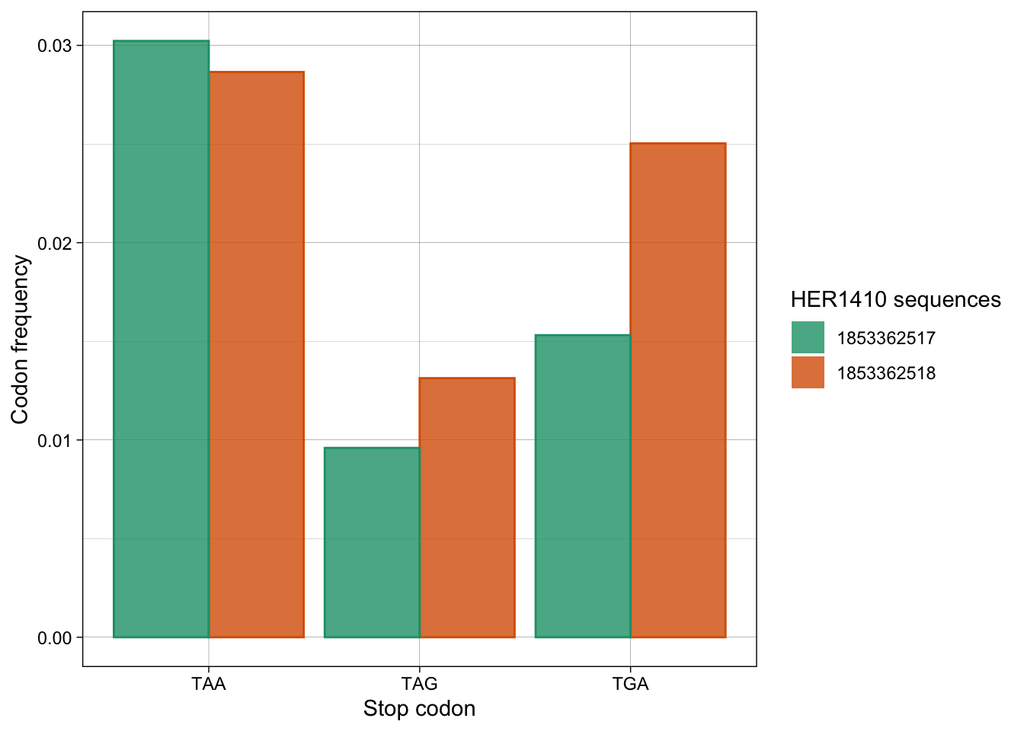

```r
# compare two files
her1410_2 <- entrez_fetch(db = "nuccore", id = her1410$ids[2],
    rettype = "fasta")
write(her1410_2, file = "her1410_2.fasta")
seq2 <- read.fasta("her1410_2.fasta")

# codon frequencies
freq1 <- count(unlist(seq1), 3, freq = TRUE)
freq2 <- count(unlist(seq2), 3, freq = TRUE)

stop1 <- freq1[which(names(freq1) == "tga" | names(freq1) ==
    "tag" | names(freq1) == "taa")]
stop2 <- freq2[which(names(freq2) == "tga" | names(freq2) ==
    "tag" | names(freq2) == "taa")]
stops <- rbind(stop1, stop2)
stops <- as.data.frame(stops)
stops$sequences <- c(her1410$ids[1], her1410$ids[2])
stops <- cbind(stops$sequences, stack(stops[, 1:3]))
names(stops) <- c("sequences", "freqs", "stop_codon")
# plot
library(ggplot2)
p <- ggplot(data = stops) + geom_bar(aes(x = toupper(stop_codon),
    y = freqs, col = sequences, fill = sequences), stat = "identity",
    position = "dodge", alpha = 0.8)
p + scale_fill_brewer(palette = "Dark2") + scale_color_brewer(palette = "Dark2") +
    theme_linedraw() + ylab("Codon frequency") + xlab("Stop codon") +
    guides(color = "none", fill = guide_legend(title = "HER1410 sequences"))
```

# Bioconductor

Bioconductor is a repository of R packages for “the analysis and comprehension of high-throughput genomic data”. It started 2002 as a platform for understanding analysis of microarray data, being the first R version 1996, and the first stable beta in 2000. Currently, it contains 2183 packages (release [3.16](https://bioconductor.org/news/bioc_3_16_release/), November 2, 2022) for diverse bioinformatics tasks. It also contains many learning resources, spanning [vignettes](https://bioconductor.org/help/package-vignettes/), [course materials](https://bioconductor.org/help/course-materials/), and [workflows](https://bioconductor.org/packages/release/BiocViews.html#___AnnotationData).

The diversity of packages in Bioconductor allows working with widely used bioinformatics apps and file formats (fasta, fastq, BAM, SAM, vcf…), for different stages of sequence analysis, quantification, annotation… You can explore [packages by categories](https://bioconductor.org/packages/release/BiocViews.html#___Software) on the Bioconductor site.

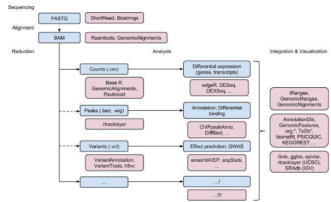

Illustrative description elaborating the different file types at various stages in a typical analysis, with the package names (in pink boxes) that one will use for each stage. From: https://www.bioconductor.org/packages/release/workflows/vignettes/sequencing/inst/doc/sequencing.html

Some of the most common Bioconductor packages and functions are:

- [**GenomicRanges**](http://bioconductor.org/packages/release/bioc/html/GenomicRanges.html): ‘Ranges’ to describe data and annotation; `GRanges()`, `GRangesList()`
- [**Biostrings**](https://bioconductor.org/packages/release/bioc/html/Biostrings.html): DNA and other sequences, `DNAStringSet()`
- [**GenomicAlignments**](https://bioconductor.org/packages/release/bioc/html/GenomicAlignments.html): Aligned reads; `GAlignemts()` and friends
- [**GenomicFeatures**](https://bioconductor.org/packages/release/bioc/html/GenomicFeatures.html), [**AnnotationDbi**](https://bioconductor.org/packages/release/bioc/html/AnnotationDbi.html): annotation resources, `TxDb`, and `org` packages.
- [**SummarizedExperiment**](https://bioconductor.org/packages/release/bioc/html/SummarizedExperiment.html): coordinating experimental data
- [**rtracklayer**](https://bioconductor.org/packages/release/bioc/html/rtracklayer.html): import Genome annotations e.g BED, WIG, GTF, etc.
- [**Annotationhub**](https://bioconductor.org/packages/release/bioc/vignettes/AnnotationHub/inst/doc/AnnotationHub.html): access to Ensembl, UCSC, NCBI and other databases.

I recommend you to check the examples in the reference 9 below and other [workflows](https://bioconductor.org/packages/release/BiocViews.html#___AnnotationData) that you can find at Bioconductor.

# References

1. *R in action.* Robert I. Kabacoff. March 2022 ISBN 9781617296055
2. Regular expressions in R: https://rstudio-pubs-static.s3.amazonaws.com/74603_76cd14d5983f47408fdf0b323550b846.html
3. R Programming for Data Science (Chapter 17): https://bookdown.org/rdpeng/rprogdatascience/
4. A little book of R for bioinformatics: https://a-little-book-of-r-for-bioinformatics.readthedocs.io/en/latest/index.html
5. *rentrez* vignette: https://cran.r-project.org/web/packages/rentrez/vignettes/rentrez_tutorial.html
6. Biostrings: https://kasperdanielhansen.github.io/genbioconductor/html/Biostrings.html
7. Example of the generation of multiple sequence alignments and phylogenies with R: https://rpubs.com/bhuvic/828540
8. Where do I start using Bioconductor: http://lcolladotor.github.io/2014/10/16/startbioc/#.Y4ZCaOyZP0p
9. Bioconductor Workflow: Introduction to Bioconductor for Sequence Data: https://www.bioconductor.org/packages/release/workflows/vignettes/sequencing/inst/doc/sequencing.html

# Exercises

#### Write a function that, given an input name:

#### 1-. It downloads a sequence from the nucleotide database in Genbank. The function needs to check if the different available sequences for that name are identical and rule out duplicates.

#### 2-. It plots the nucleotide composition (% of A, C, G and T) and the amino acids frequencies in the 6 possible frames.

#### 3-. It should also download the protein sequences with that name and count the number of enzymes (you can use *ase* as keyword) and the number orfans (*hypothetical protein*).

#### Test your function with the nucleotide sequences of the plasmids pSE-12228-03 and pCERC7.

# [Course home](https://mredrejo.github.io/HPBBM2022/)

### Lesson 9: Data input and output in R

### Lesson 10: Write your own functions

### Lesson 11: Plots

### Lesson 12: Data management

### Lesson 13: Advanced plots with ggplot

### Extra Lesson: Introduction to R projects, R Markdown and Quarto.